# Reproducible Research: Peer Assessment 1

### Loading and preprocessing the data

```r
pa1 <- read.csv("activity.csv")
```

## In this section of the assignment missing values will be ignored

```r
pa11 <- pa1[!is.na(pa1$step),]
```

## What is mean total number of steps taken per day?

### 1) Make a histogram of the total number of steps take each day

```r
library(dplyr)
```

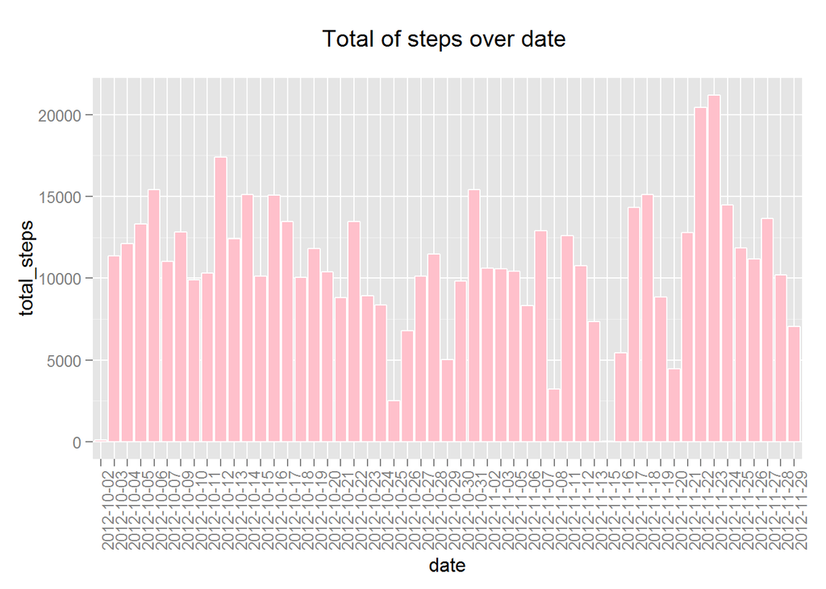

```r
library(ggplot2)
pa1sumbd <- group_by(pa11,date) %>% summarize(sum(steps))
names(pa1sumbd)[2] <- 'total_steps'
g <- ggplot(pa1sumbd,aes(x=date ,y=total_steps))
plot1 <-
  g + geom_bar(stat="identity", position="identity",fill="pink",
               colour="white") +
  theme(axis.text.x = element_text(angle = 90, hjust = 1)) +
  ggtitle("Total of steps over date \n")
print(plot1)
```

### 2) Calculate and report mean and median of number steps per day

```r
mnd <- format(round(mean(pa1sumbd$total_steps),2),nsall=2)
med <- format(round(median(pa1sumbd$total_steps),2),nsall=2)
```

The mean total number of steps taken per day is 10766.19. The median total number of steps taken per day is 10765.

## What is the average daily activity pattern?

### 1) Time series plot (i.e type =“l”) of interval (x-axis) and average number of steps across all days (y-axis)

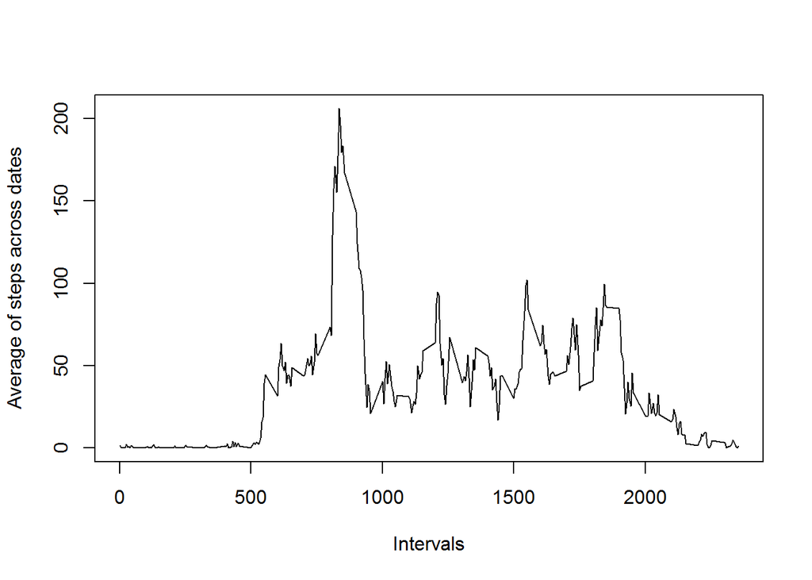

```r
pa11 <- pa1[!is.na(pa1$step),]
pa1avebi <- group_by(pa11,interval) %>% summarize(mean(steps))
names(pa1avebi)[2] <- 'average_steps'
with(pa1avebi,plot(interval,average_steps, type="l",
                   ylab="Average of steps across dates",
                   xlab="Intervals"))
```

### 2) Which interval on average across all days contains the maximum number of steps?

```r
msteps <- pa1avebi[(pa1avebi$average_steps == max(pa1avebi$average_steps)),1]
```

The interval with the maximum average number of steps across all days is 835.

## Imputing missing values

### 1) Number rows with missing values

```r
nb <- nrow(pa1[(is.na(pa1$steps)),])
```

The number of rows in the dataset missing values in the steps variable is 2304.

### 2) Replace missing values with the mean values of the same intervals across all dates

```r
pa1mg  <-
  merge(pa1,pa1avebi,by.x="interval",by.y="interval", all=TRUE)
pa1mg$nsteps <-
  ifelse(is.na(pa1mg$steps),pa1mg$average_steps,pa1mg$steps)
pa1mg$steps <- pa1mg$nsteps
```

### 3) New dataset with the missing filled-in is pa1mg

### 4) Histogram of the total number of steps taken each day.

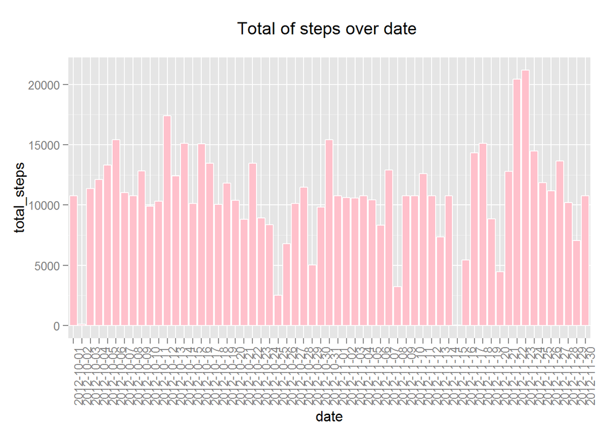

```r
#group by date and sum the steps
pa1mgsumbd <- group_by(pa1mg,date) %>% summarize(sum(steps))
names(pa1mgsumbd)[2] <- 'total_steps'
library(ggplot2)
g <- ggplot(pa1mgsumbd,aes(x=date ,y=total_steps))
plot10 <- g +
  geom_bar(stat="identity", position="identity",fill="pink",
           colour="white") +
  theme(axis.text.x = element_text(angle = 90, hjust = 1)) +
  ggtitle("Total of steps over date \n")
print(plot10)
```

```r
fmn <- format(round(mean(pa1mgsumbd$total_steps),2),nsall=2)
fmd <- format(round(median(pa1mgsumbd$total_steps),2),nsall=2)
```

The mean total number of steps taken per day is 10766.19. The median total number of steps taken per day is 10766.19.

Compare the mean and median values in the 2 cases: Without the NAs and with the NAs replaced by the average values.

```r
library(xtable)
x <- data.frame(case=c("Without_na","na_replaced_by_mean"),
                mean=c(mnd,fmn),
                median=c(med,fmd))
xt <- x
print(xt,type="html")
```

```
##                  case     mean   median
## 1          Without_na 10766.19    10765
## 2 na_replaced_by_mean 10766.19 10766.19
```

## Are there differences in activity patterns between weekdays and weekends?

### 1) Create a factor with 2 levels weekday and weekend

```r
# create the variable day saying the day of the week
pa1mg$day <- weekdays(as.Date(pa1mg$date))


#function identifying weekday and weekend as a vector
wdwe <- function(a) {
  res <<- ""
  for (i in 1:length(a)) {
        if (a[i] %in%
              c("Monday","Tuesday","Wednesday","Thursday",
                "Friday")) { res[i] <<- "weekday"
                             }
        else {
          res[i] <<- "weekend"
          }
        }
  res
  }

# create the variable wdwe identifying weekday and weekend
pa1mg$wdwe <- wdwe(pa1mg$day)

# Compute the average steps for each interval during weekday
pa1mgmnwd <-
  filter(pa1mg,wdwe=="weekday") %>%
  group_by(interval) %>% summarize(mean(steps))
names(pa1mgmnwd)[2] <- 'average_steps'
pa1mgmnwd$wdwe <- rep("weekday",nrow(pa1mgmnwd))

# Compute the average steps for each interval during weekend
pa1mgmnwe <-
  filter(pa1mg,wdwe=="weekend") %>%
  group_by(interval) %>% summarize(mean(steps))
names(pa1mgmnwe)[2] <- 'average_steps'
pa1mgmnwe$wdwe <- rep("weekend",nrow(pa1mgmnwe))

# Combine the 2 sets of data
pa1mgmn <- rbind(pa1mgmnwd,pa1mgmnwe)

#transform the variable wdwe into factor for lattice panel plots
pa1mgmn$wdwe <- as.factor(pa1mgmn$wdwe)
```